# Molecular Solubility Prediction Using ESOL Dataset

This notebook builds a regression model to predict aqueous solubility (log mol/L) from molecular structures in the Delaney ESOL dataset.

```python
# Step 1: Import required libraries

import pandas as pd
import numpy as np
from rdkit import Chem
from rdkit.Chem import AllChem
from sklearn.model_selection import train_test_split
from sklearn.ensemble import RandomForestRegressor
from sklearn.metrics import mean_squared_error, r2_score
import matplotlib.pyplot as plt
```

# We import libraries needed for data processing, molecule handling, model building, evaluation, and visualization.

```python
# Step 2: Load the dataset

data = pd.read_csv('delaney.csv')  # Update this path if needed
data.head()
```

|  | Compound ID | measured log(solubility:mol/L) | ESOL predicted log(solubility:mol/L) | SMILES |
| --- | --- | --- | --- | --- |
| 0 | 1,1,1,2-Tetrachloroethane | -2.18 | -2.794 | ClCC(Cl)(Cl)Cl |
| 1 | 1,1,1-Trichloroethane | -2.00 | -2.232 | CC(Cl)(Cl)Cl |
| 2 | 1,1,2,2-Tetrachloroethane | -1.74 | -2.549 | ClC(Cl)C(Cl)Cl |
| 3 | 1,1,2-Trichloroethane | -1.48 | -1.961 | ClCC(Cl)Cl |
| 4 | 1,1,2-Trichlorotrifluoroethane | -3.04 | -3.077 | FC(F)(Cl)C(F)(Cl)Cl |

# Load the molecular solubility dataset and display the first few rows.

```python
# Step 3: Convert SMILES to molecular fingerprints

def smiles_to_fingerprint(smiles):
    mol = Chem.MolFromSmiles(smiles)
    if mol is None:
        return None
    fp = AllChem.GetMorganFingerprintAsBitVect(mol, 2, nBits=1024)
    arr = np.zeros((1,), dtype=int)
    AllChem.DataStructs.ConvertToNumpyArray(fp, arr)
    return arr

data['fingerprint'] = data['SMILES'].apply(smiles_to_fingerprint)
data = data.dropna(subset=['fingerprint'])
```

# Transform SMILES strings into Morgan fingerprints to numerically represent molecules for machine learning.

```python
# Step 4: Prepare features and labels

X = np.stack(data['fingerprint'].values)
y = data['measured log(solubility:mol/L)'].values
```

# Separate features (molecular fingerprints) and target variable (measured solubility).

```python
# Step 5: Split data into training and testing sets

X_train, X_test, y_train, y_test = train_test_split(X, y, test_size=0.2, random_state=42)

print(f"Training samples: {X_train.shape[0]}")
print(f"Testing samples: {X_test.shape[0]}")
```

```
Training samples: 915
Testing samples: 229
```

# Split data 80-20 for training and evaluation.

```python
# Step 6: Train Random Forest Regressor

model = RandomForestRegressor(n_estimators=100, random_state=42)
model.fit(X_train, y_train)
```

```
RandomForestRegressor(random_state=42)
```

# Train a robust Random Forest regression model to predict solubility.

```python
# Step 7: Evaluate the model

y_pred = model.predict(X_test)

mse = mean_squared_error(y_test, y_pred)
r2 = r2_score(y_test, y_pred)

print(f"Mean Squared Error (MSE): {mse:.3f}")
print(f"R-squared (R2) Score: {r2:.3f}")
```

```
Mean Squared Error (MSE): 1.430
R-squared (R2) Score: 0.672
```

# Evaluate model performance using Mean Squared Error (MSE) and R² score.

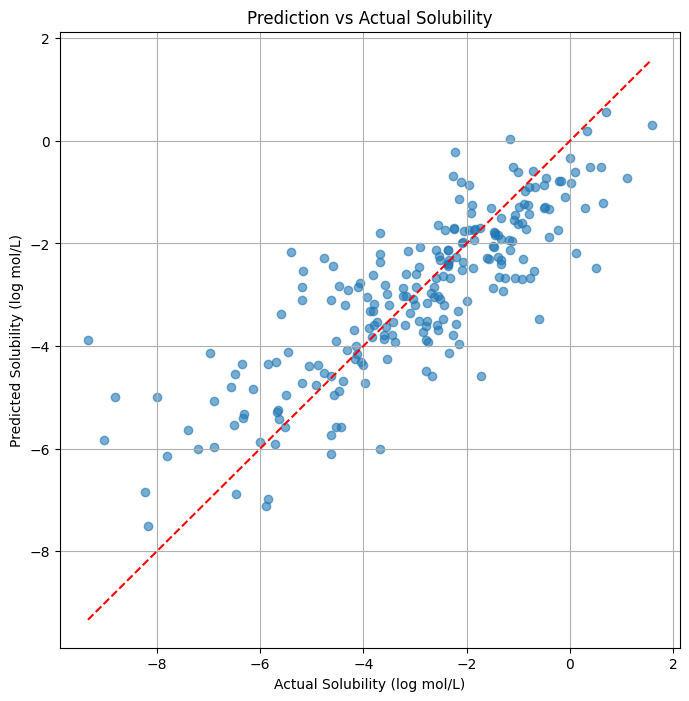

```python
# Step 8: Visualize actual vs predicted solubility

plt.figure(figsize=(8, 8))
plt.scatter(y_test, y_pred, alpha=0.6)
plt.plot([min(y_test), max(y_test)], [min(y_test), max(y_test)], color='red', linestyle='--')
plt.xlabel('Actual Solubility (log mol/L)')
plt.ylabel('Predicted Solubility (log mol/L)')
plt.title('Prediction vs Actual Solubility')
plt.grid(True)
plt.show()
```

# Visualize the comparison of actual vs predicted solubility values. Ideally, points should lie close to the red dashed perfect prediction line.

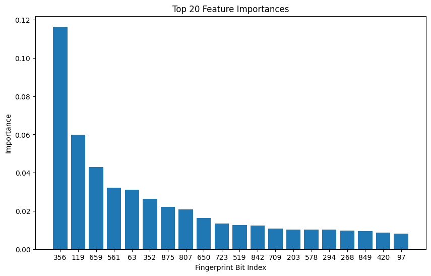

```python
# Step 9: Feature importance plot

importances = model.feature_importances_

# Plot top 20 most important fingerprint features
indices = np.argsort(importances)[::-1][:20]
plt.figure(figsize=(10, 6))
plt.title("Top 20 Feature Importances")
plt.bar(range(len(indices)), importances[indices], align='center')
plt.xlabel("Fingerprint Bit Index")
plt.ylabel("Importance")
plt.xticks(range(len(indices)), indices)
plt.show()
```

# Step 9: Analyze Feature Importances

Understanding which molecular fingerprint bits are most influential helps interpret what chemical features impact solubility prediction.

# This bar plot shows the top 20 fingerprint bits ranked by their importance in predicting solubility.

Interpreting these bits can help identify molecular substructures affecting solubility.

```python
from sklearn.model_selection import RandomizedSearchCV

# Define parameter grid
param_dist = {
    'n_estimators': [100, 200, 300],
    'max_depth': [None, 10, 20, 30],
    'min_samples_split': [2, 5, 10]
}

# Initialize RandomizedSearchCV
rand_search = RandomizedSearchCV(
    estimator=RandomForestRegressor(random_state=42),
    param_distributions=param_dist,
    n_iter=10,
    cv=3,
    scoring='neg_mean_squared_error',
    random_state=42,
    n_jobs=-1
)

# Run randomized search on training data
rand_search.fit(X_train, y_train)

print("Best Parameters:", rand_search.best_params_)

# Evaluate best model on test set
best_model = rand_search.best_estimator_
y_pred_tuned = best_model.predict(X_test)
print(f"Tuned Model MSE: {mean_squared_error(y_test, y_pred_tuned):.3f}")
print(f"Tuned Model R2: {r2_score(y_test, y_pred_tuned):.3f}")
```

```
Best Parameters: {'n_estimators': 200, 'min_samples_split': 5, 'max_depth': 30}
Tuned Model MSE: 1.428
Tuned Model R2: 0.672
```

# Step 10: Hyperparameter Tuning with Randomized Search

Tuning hyperparameters of Random Forest may improve prediction performance.

# RandomizedSearchCV samples different hyperparameter combinations and uses cross-validation to find the best set according to mean squared error. The tuned model is then evaluated and compared with the initial model.

# Project Report: Molecular Solubility Prediction Using Machine Learning

## Project Overview

This project aims to predict the aqueous solubility of small molecules using chemical structure data from the Delaney ESOL dataset. Molecular solubility is a critical property in drug discovery affecting absorption and bioavailability.

## Dataset

The Delaney ESOL dataset contains experimentally measured solubility values (log mol/L) and corresponding molecular SMILES strings representing chemical structures.

## Methodology

- **Data Preparation:**  
  Converted SMILES strings to Morgan fingerprints (1024-bit vectors) capturing molecular substructures.
- **Modeling:**  
  Trained a Random Forest regression model to learn the relationship between molecular fingerprints and solubility.
- **Evaluation:**  
  Model performance was assessed by Mean Squared Error (MSE) and R² score on a held-out test set.
- **Interpretation:**  
  Feature importances from the Random Forest model were analyzed to understand influential chemical features.

## Future Work

- Explore gradient boosting models or deep learning architectures such as graph neural networks for molecular encoding.
- Incorporate additional molecular descriptors or physicochemical properties.
- Validate the model on external solubility or drug efficacy datasets.
- Analyze model predictions for confounding factors and domain applicability.

## Conclusion

This project demonstrates the ability to preprocess chemical data, apply classical machine learning models, and interpret results meaningfully for pharmaceutical and drug discovery applications. It showcases skills relevant to Bayer’s AI-driven R&D and chemoinformatics focus.